# Risk Factor Analysis

## Outcome Variable

**Outcome Variable:** pers_wast

## Predictor Variables

**Intervention Variable:** perdiar6

**Adjustment Set:**

unadjusted

## Stratifying Variables

The analysis was stratified on these variable(s):

- agecat
- studyid
- country

## Data Summary

| agecat | studyid | country | perdiar6 | pers_wast | n_cell | n |
| --- | --- | --- | --- | --- | --- | --- |
| 0-24 months | ki0047075b-MAL-ED | BANGLADESH | (0%, 5%] | 0 | 90 | 248 |
| 0-24 months | ki0047075b-MAL-ED | BANGLADESH | (0%, 5%] | 1 | 6 | 248 |
| 0-24 months | ki0047075b-MAL-ED | BANGLADESH | 0% | 0 | 69 | 248 |
| 0-24 months | ki0047075b-MAL-ED | BANGLADESH | 0% | 1 | 4 | 248 |
| 0-24 months | ki0047075b-MAL-ED | BANGLADESH | >5% | 0 | 76 | 248 |
| 0-24 months | ki0047075b-MAL-ED | BANGLADESH | >5% | 1 | 3 | 248 |
| 0-24 months | ki0047075b-MAL-ED | BRAZIL | (0%, 5%] | 0 | 15 | 217 |
| 0-24 months | ki0047075b-MAL-ED | BRAZIL | (0%, 5%] | 1 | 0 | 217 |
| 0-24 months | ki0047075b-MAL-ED | BRAZIL | 0% | 0 | 198 | 217 |
| 0-24 months | ki0047075b-MAL-ED | BRAZIL | 0% | 1 | 2 | 217 |
| 0-24 months | ki0047075b-MAL-ED | BRAZIL | >5% | 0 | 2 | 217 |
| 0-24 months | ki0047075b-MAL-ED | BRAZIL | >5% | 1 | 0 | 217 |
| 0-24 months | ki0047075b-MAL-ED | INDIA | (0%, 5%] | 0 | 118 | 241 |
| 0-24 months | ki0047075b-MAL-ED | INDIA | (0%, 5%] | 1 | 11 | 241 |
| 0-24 months | ki0047075b-MAL-ED | INDIA | 0% | 0 | 48 | 241 |
| 0-24 months | ki0047075b-MAL-ED | INDIA | 0% | 1 | 4 | 241 |
| 0-24 months | ki0047075b-MAL-ED | INDIA | >5% | 0 | 54 | 241 |
| 0-24 months | ki0047075b-MAL-ED | INDIA | >5% | 1 | 6 | 241 |
| 0-24 months | ki0047075b-MAL-ED | NEPAL | (0%, 5%] | 0 | 76 | 238 |
| 0-24 months | ki0047075b-MAL-ED | NEPAL | (0%, 5%] | 1 | 1 | 238 |
| 0-24 months | ki0047075b-MAL-ED | NEPAL | 0% | 0 | 78 | 238 |
| 0-24 months | ki0047075b-MAL-ED | NEPAL | 0% | 1 | 3 | 238 |
| 0-24 months | ki0047075b-MAL-ED | NEPAL | >5% | 0 | 80 | 238 |
| 0-24 months | ki0047075b-MAL-ED | NEPAL | >5% | 1 | 0 | 238 |
| 0-24 months | ki0047075b-MAL-ED | PERU | (0%, 5%] | 0 | 93 | 284 |
| 0-24 months | ki0047075b-MAL-ED | PERU | (0%, 5%] | 1 | 0 | 284 |
| 0-24 months | ki0047075b-MAL-ED | PERU | 0% | 0 | 71 | 284 |
| 0-24 months | ki0047075b-MAL-ED | PERU | 0% | 1 | 1 | 284 |
| 0-24 months | ki0047075b-MAL-ED | PERU | >5% | 0 | 119 | 284 |
| 0-24 months | ki0047075b-MAL-ED | PERU | >5% | 1 | 0 | 284 |

[output cut: 234 more lines]

The following strata were considered:

- agecat: 0-24 months, studyid: ki0047075b-MAL-ED, country: BANGLADESH
- agecat: 0-24 months, studyid: ki0047075b-MAL-ED, country: BRAZIL
- agecat: 0-24 months, studyid: ki0047075b-MAL-ED, country: INDIA
- agecat: 0-24 months, studyid: ki0047075b-MAL-ED, country: NEPAL
- agecat: 0-24 months, studyid: ki0047075b-MAL-ED, country: PERU
- agecat: 0-24 months, studyid: ki0047075b-MAL-ED, country: SOUTH AFRICA
- agecat: 0-24 months, studyid: ki0047075b-MAL-ED, country: TANZANIA, UNITED REPUBLIC OF
- agecat: 0-24 months, studyid: ki1000109-ResPak, country: PAKISTAN
- agecat: 0-24 months, studyid: ki1017093-NIH-Birth, country: BANGLADESH
- agecat: 0-24 months, studyid: ki1017093b-PROVIDE, country: BANGLADESH
- agecat: 0-24 months, studyid: ki1017093c-NIH-Crypto, country: BANGLADESH
- agecat: 0-24 months, studyid: ki1114097-CMIN, country: BANGLADESH
- agecat: 0-24 months, studyid: ki1114097-CMIN, country: BRAZIL
- agecat: 0-24 months, studyid: ki1114097-CMIN, country: GUINEA-BISSAU
- agecat: 0-24 months, studyid: ki1114097-CMIN, country: PERU
- agecat: 0-24 months, studyid: ki1114097-CONTENT, country: PERU
- agecat: 0-6 months, studyid: ki0047075b-MAL-ED, country: BANGLADESH
- agecat: 0-6 months, studyid: ki0047075b-MAL-ED, country: BRAZIL
- agecat: 0-6 months, studyid: ki0047075b-MAL-ED, country: INDIA
- agecat: 0-6 months, studyid: ki0047075b-MAL-ED, country: NEPAL
- agecat: 0-6 months, studyid: ki0047075b-MAL-ED, country: PERU
- agecat: 0-6 months, studyid: ki0047075b-MAL-ED, country: SOUTH AFRICA
- agecat: 0-6 months, studyid: ki0047075b-MAL-ED, country: TANZANIA, UNITED REPUBLIC OF
- agecat: 0-6 months, studyid: ki1000109-ResPak, country: PAKISTAN
- agecat: 0-6 months, studyid: ki1017093b-PROVIDE, country: BANGLADESH
- agecat: 0-6 months, studyid: ki1114097-CMIN, country: BANGLADESH
- agecat: 0-6 months, studyid: ki1114097-CMIN, country: PERU
- agecat: 0-6 months, studyid: ki1114097-CONTENT, country: PERU
- agecat: 6-24 months, studyid: ki0047075b-MAL-ED, country: BANGLADESH
- agecat: 6-24 months, studyid: ki0047075b-MAL-ED, country: BRAZIL
- agecat: 6-24 months, studyid: ki0047075b-MAL-ED, country: INDIA
- agecat: 6-24 months, studyid: ki0047075b-MAL-ED, country: NEPAL
- agecat: 6-24 months, studyid: ki0047075b-MAL-ED, country: PERU
- agecat: 6-24 months, studyid: ki0047075b-MAL-ED, country: SOUTH AFRICA
- agecat: 6-24 months, studyid: ki0047075b-MAL-ED, country: TANZANIA, UNITED REPUBLIC OF
- agecat: 6-24 months, studyid: ki1000109-ResPak, country: PAKISTAN
- agecat: 6-24 months, studyid: ki1017093-NIH-Birth, country: BANGLADESH
- agecat: 6-24 months, studyid: ki1017093b-PROVIDE, country: BANGLADESH
- agecat: 6-24 months, studyid: ki1017093c-NIH-Crypto, country: BANGLADESH
- agecat: 6-24 months, studyid: ki1114097-CMIN, country: BANGLADESH
- agecat: 6-24 months, studyid: ki1114097-CMIN, country: BRAZIL
- agecat: 6-24 months, studyid: ki1114097-CMIN, country: GUINEA-BISSAU
- agecat: 6-24 months, studyid: ki1114097-CMIN, country: PERU
- agecat: 6-24 months, studyid: ki1114097-CONTENT, country: PERU

### Dropped Strata

Some strata were dropped due to rare outcomes:

- agecat: 0-24 months, studyid: ki0047075b-MAL-ED, country: BANGLADESH
- agecat: 0-24 months, studyid: ki0047075b-MAL-ED, country: BRAZIL
- agecat: 0-24 months, studyid: ki0047075b-MAL-ED, country: INDIA
- agecat: 0-24 months, studyid: ki0047075b-MAL-ED, country: NEPAL
- agecat: 0-24 months, studyid: ki0047075b-MAL-ED, country: PERU
- agecat: 0-24 months, studyid: ki0047075b-MAL-ED, country: SOUTH AFRICA
- agecat: 0-24 months, studyid: ki0047075b-MAL-ED, country: TANZANIA, UNITED REPUBLIC OF
- agecat: 0-24 months, studyid: ki1017093b-PROVIDE, country: BANGLADESH
- agecat: 0-24 months, studyid: ki1114097-CMIN, country: BRAZIL
- agecat: 0-24 months, studyid: ki1114097-CMIN, country: GUINEA-BISSAU
- agecat: 0-24 months, studyid: ki1114097-CMIN, country: PERU
- agecat: 0-24 months, studyid: ki1114097-CONTENT, country: PERU
- agecat: 0-6 months, studyid: ki0047075b-MAL-ED, country: BANGLADESH
- agecat: 0-6 months, studyid: ki0047075b-MAL-ED, country: BRAZIL
- agecat: 0-6 months, studyid: ki0047075b-MAL-ED, country: INDIA
- agecat: 0-6 months, studyid: ki0047075b-MAL-ED, country: NEPAL
- agecat: 0-6 months, studyid: ki0047075b-MAL-ED, country: PERU
- agecat: 0-6 months, studyid: ki0047075b-MAL-ED, country: SOUTH AFRICA
- agecat: 0-6 months, studyid: ki0047075b-MAL-ED, country: TANZANIA, UNITED REPUBLIC OF
- agecat: 0-6 months, studyid: ki1017093b-PROVIDE, country: BANGLADESH
- agecat: 0-6 months, studyid: ki1114097-CMIN, country: BANGLADESH
- agecat: 0-6 months, studyid: ki1114097-CMIN, country: PERU
- agecat: 0-6 months, studyid: ki1114097-CONTENT, country: PERU
- agecat: 6-24 months, studyid: ki0047075b-MAL-ED, country: BANGLADESH
- agecat: 6-24 months, studyid: ki0047075b-MAL-ED, country: BRAZIL
- agecat: 6-24 months, studyid: ki0047075b-MAL-ED, country: NEPAL
- agecat: 6-24 months, studyid: ki0047075b-MAL-ED, country: PERU
- agecat: 6-24 months, studyid: ki0047075b-MAL-ED, country: SOUTH AFRICA
- agecat: 6-24 months, studyid: ki0047075b-MAL-ED, country: TANZANIA, UNITED REPUBLIC OF
- agecat: 6-24 months, studyid: ki1114097-CMIN, country: BRAZIL
- agecat: 6-24 months, studyid: ki1114097-CMIN, country: GUINEA-BISSAU
- agecat: 6-24 months, studyid: ki1114097-CMIN, country: PERU
- agecat: 6-24 months, studyid: ki1114097-CONTENT, country: PERU

## Methods Detail

We’re interested in the causal parameters $E[Y_a]$ for all values of $a \in \mathcal{A}$. These parameters represent the mean outcome if, possibly contrary to fact, we intervened to set all units to have $A=a$. Under the randomization and positivity assumptions, these are identified by the statistical parameters $\psi_a=E_W[E_{Y|A,W}(Y|A=a,W)]$. In addition, we’re interested in the mean of $Y$, $E[Y]$ under no intervention (the observed mean). We will estimate these parameters by using SuperLearner to fit the relevant likelihood factors – $E_{Y|A,W}(Y|A=a,W)$ and $p(A=a|W)$, and then updating our likelihood fit using a joint TMLE.

For unadjusted analyses ($W=\{\}$), initial likelihoods were estimated using Lrnr_glm to estimate the simple $E(Y|A)$ and Lrnr_mean to estimate $p(A)$. For adjusted analyses, a small library containing Lrnr_glmnet, Lrnr_xgboost, and Lrnr_mean was used.

Having estimated these parameters, we will then use the delta method to estimate relative risks and attributable risks relative to a prespecified baseline level of $A$.

# Results Detail

## Results Plots

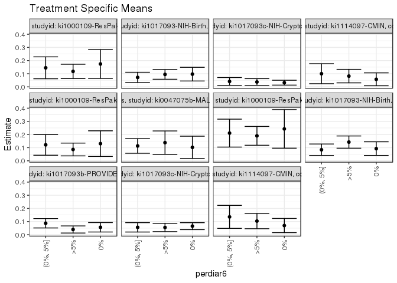

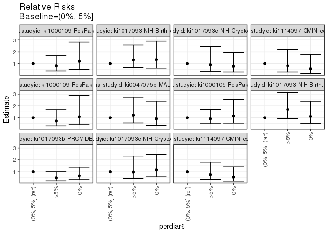

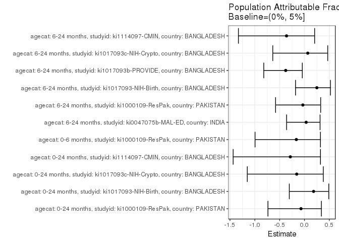

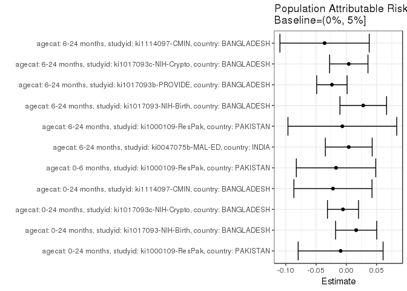

## Results Table

### Parameter: TSM

| agecat | studyid | country | intervention_level | baseline_level | estimate | ci_lower | ci_upper |
| --- | --- | --- | --- | --- | --- | --- | --- |
| 0-24 months | ki1000109-ResPak | PAKISTAN | (0%, 5%] | NA | 0.1449275 | 0.0616999 | 0.2281551 |
| 0-24 months | ki1000109-ResPak | PAKISTAN | 0% | NA | 0.1739130 | 0.0641604 | 0.2836657 |
| 0-24 months | ki1000109-ResPak | PAKISTAN | >5% | NA | 0.1176471 | 0.0633899 | 0.1719042 |
| 0-24 months | ki1017093-NIH-Birth | BANGLADESH | (0%, 5%] | NA | 0.0718563 | 0.0326517 | 0.1110609 |
| 0-24 months | ki1017093-NIH-Birth | BANGLADESH | 0% | NA | 0.0967742 | 0.0446880 | 0.1488603 |
| 0-24 months | ki1017093-NIH-Birth | BANGLADESH | >5% | NA | 0.0946502 | 0.0578101 | 0.1314903 |
| 0-24 months | ki1017093c-NIH-Crypto | BANGLADESH | (0%, 5%] | NA | 0.0411765 | 0.0112872 | 0.0710657 |
| 0-24 months | ki1017093c-NIH-Crypto | BANGLADESH | 0% | NA | 0.0318841 | 0.0133322 | 0.0504359 |
| 0-24 months | ki1017093c-NIH-Crypto | BANGLADESH | >5% | NA | 0.0372093 | 0.0118920 | 0.0625267 |
| 0-24 months | ki1114097-CMIN | BANGLADESH | (0%, 5%] | NA | 0.1000000 | 0.0239428 | 0.1760572 |
| 0-24 months | ki1114097-CMIN | BANGLADESH | 0% | NA | 0.0574713 | 0.0084700 | 0.1064726 |
| 0-24 months | ki1114097-CMIN | BANGLADESH | >5% | NA | 0.0818182 | 0.0304981 | 0.1331383 |
| 0-6 months | ki1000109-ResPak | PAKISTAN | (0%, 5%] | NA | 0.1212121 | 0.0423083 | 0.2001159 |
| 0-6 months | ki1000109-ResPak | PAKISTAN | 0% | NA | 0.1304348 | 0.0329081 | 0.2279615 |
| 0-6 months | ki1000109-ResPak | PAKISTAN | >5% | NA | 0.0859375 | 0.0372823 | 0.1345927 |
| 6-24 months | ki0047075b-MAL-ED | INDIA | (0%, 5%] | NA | 0.1129032 | 0.0570796 | 0.1687268 |
| 6-24 months | ki0047075b-MAL-ED | INDIA | 0% | NA | 0.1020408 | 0.0171018 | 0.1869799 |
| 6-24 months | ki0047075b-MAL-ED | INDIA | >5% | NA | 0.1379310 | 0.0489949 | 0.2268672 |
| 6-24 months | ki1000109-ResPak | PAKISTAN | (0%, 5%] | NA | 0.2105263 | 0.1044327 | 0.3166200 |
| 6-24 months | ki1000109-ResPak | PAKISTAN | 0% | NA | 0.2424242 | 0.0958530 | 0.3889955 |
| 6-24 months | ki1000109-ResPak | PAKISTAN | >5% | NA | 0.1896552 | 0.1181408 | 0.2611695 |
| 6-24 months | ki1017093-NIH-Birth | BANGLADESH | (0%, 5%] | NA | 0.0838710 | 0.0401884 | 0.1275535 |
| 6-24 months | ki1017093-NIH-Birth | BANGLADESH | 0% | NA | 0.0924370 | 0.0403442 | 0.1445298 |
| 6-24 months | ki1017093-NIH-Birth | BANGLADESH | >5% | NA | 0.1422018 | 0.0957923 | 0.1886113 |
| 6-24 months | ki1017093b-PROVIDE | BANGLADESH | (0%, 5%] | NA | 0.0871369 | 0.0514996 | 0.1227743 |
| 6-24 months | ki1017093b-PROVIDE | BANGLADESH | 0% | NA | 0.0566038 | 0.0206553 | 0.0925523 |
| 6-24 months | ki1017093b-PROVIDE | BANGLADESH | >5% | NA | 0.0398010 | 0.0127527 | 0.0668493 |
| 6-24 months | ki1017093c-NIH-Crypto | BANGLADESH | (0%, 5%] | NA | 0.0562500 | 0.0205236 | 0.0919764 |
| 6-24 months | ki1017093c-NIH-Crypto | BANGLADESH | 0% | NA | 0.0652819 | 0.0388893 | 0.0916745 |
| 6-24 months | ki1017093c-NIH-Crypto | BANGLADESH | >5% | NA | 0.0550000 | 0.0233814 | 0.0866186 |
| 6-24 months | ki1114097-CMIN | BANGLADESH | (0%, 5%] | NA | 0.1355932 | 0.0480612 | 0.2231253 |
| 6-24 months | ki1114097-CMIN | BANGLADESH | 0% | NA | 0.0697674 | 0.0158179 | 0.1237170 |
| 6-24 months | ki1114097-CMIN | BANGLADESH | >5% | NA | 0.1037736 | 0.0456015 | 0.1619456 |

### Parameter: E(Y)

| agecat | studyid | country | intervention_level | baseline_level | estimate | ci_lower | ci_upper |
| --- | --- | --- | --- | --- | --- | --- | --- |
| 0-24 months | ki1000109-ResPak | PAKISTAN | NA | NA | 0.1354582 | 0.0930379 | 0.1778785 |
| 0-24 months | ki1017093-NIH-Birth | BANGLADESH | NA | NA | 0.0880150 | 0.0639627 | 0.1120673 |
| 0-24 months | ki1017093c-NIH-Crypto | BANGLADESH | NA | NA | 0.0356164 | 0.0221630 | 0.0490699 |
| 0-24 months | ki1114097-CMIN | BANGLADESH | NA | NA | 0.0778210 | 0.0450051 | 0.1106369 |
| 0-6 months | ki1000109-ResPak | PAKISTAN | NA | NA | 0.1041667 | 0.0654385 | 0.1428949 |
| 6-24 months | ki0047075b-MAL-ED | INDIA | NA | NA | 0.1168831 | 0.0753620 | 0.1584042 |
| 6-24 months | ki1000109-ResPak | PAKISTAN | NA | NA | 0.2038835 | 0.1487329 | 0.2590341 |
| 6-24 months | ki1017093-NIH-Birth | BANGLADESH | NA | NA | 0.1117886 | 0.0839169 | 0.1396604 |
| 6-24 months | ki1017093b-PROVIDE | BANGLADESH | NA | NA | 0.0632280 | 0.0437545 | 0.0827015 |
| 6-24 months | ki1017093c-NIH-Crypto | BANGLADESH | NA | NA | 0.0602582 | 0.0425793 | 0.0779372 |
| 6-24 months | ki1114097-CMIN | BANGLADESH | NA | NA | 0.0996016 | 0.0624798 | 0.1367234 |

### Parameter: RR

| agecat | studyid | country | intervention_level | baseline_level | estimate | ci_lower | ci_upper |
| --- | --- | --- | --- | --- | --- | --- | --- |
| 0-24 months | ki1000109-ResPak | PAKISTAN | (0%, 5%] | (0%, 5%] | 1.0000000 | 1.0000000 | 1.000000 |
| 0-24 months | ki1000109-ResPak | PAKISTAN | 0% | (0%, 5%] | 1.2000000 | 0.5112307 | 2.816732 |
| 0-24 months | ki1000109-ResPak | PAKISTAN | >5% | (0%, 5%] | 0.8117647 | 0.3886498 | 1.695516 |
| 0-24 months | ki1017093-NIH-Birth | BANGLADESH | (0%, 5%] | (0%, 5%] | 1.0000000 | 1.0000000 | 1.000000 |
| 0-24 months | ki1017093-NIH-Birth | BANGLADESH | 0% | (0%, 5%] | 1.3467742 | 0.6258263 | 2.898249 |
| 0-24 months | ki1017093-NIH-Birth | BANGLADESH | >5% | (0%, 5%] | 1.3172154 | 0.6738939 | 2.574673 |
| 0-24 months | ki1017093c-NIH-Crypto | BANGLADESH | (0%, 5%] | (0%, 5%] | 1.0000000 | 1.0000000 | 1.000000 |
| 0-24 months | ki1017093c-NIH-Crypto | BANGLADESH | 0% | (0%, 5%] | 0.7743271 | 0.3054221 | 1.963127 |
| 0-24 months | ki1017093c-NIH-Crypto | BANGLADESH | >5% | (0%, 5%] | 0.9036545 | 0.3341309 | 2.443926 |
| 0-24 months | ki1114097-CMIN | BANGLADESH | (0%, 5%] | (0%, 5%] | 1.0000000 | 1.0000000 | 1.000000 |
| 0-24 months | ki1114097-CMIN | BANGLADESH | 0% | (0%, 5%] | 0.5747126 | 0.1833347 | 1.801593 |
| 0-24 months | ki1114097-CMIN | BANGLADESH | >5% | (0%, 5%] | 0.8181818 | 0.3052805 | 2.192808 |
| 0-6 months | ki1000109-ResPak | PAKISTAN | (0%, 5%] | (0%, 5%] | 1.0000000 | 1.0000000 | 1.000000 |
| 0-6 months | ki1000109-ResPak | PAKISTAN | 0% | (0%, 5%] | 1.0760870 | 0.3993030 | 2.899961 |
| 0-6 months | ki1000109-ResPak | PAKISTAN | >5% | (0%, 5%] | 0.7089844 | 0.2991993 | 1.680013 |
| 6-24 months | ki0047075b-MAL-ED | INDIA | (0%, 5%] | (0%, 5%] | 1.0000000 | 1.0000000 | 1.000000 |
| 6-24 months | ki0047075b-MAL-ED | INDIA | 0% | (0%, 5%] | 0.9037901 | 0.3432373 | 2.379801 |
| 6-24 months | ki0047075b-MAL-ED | INDIA | >5% | (0%, 5%] | 1.2216749 | 0.5420941 | 2.753193 |
| 6-24 months | ki1000109-ResPak | PAKISTAN | (0%, 5%] | (0%, 5%] | 1.0000000 | 1.0000000 | 1.000000 |
| 6-24 months | ki1000109-ResPak | PAKISTAN | 0% | (0%, 5%] | 1.1515152 | 0.5241326 | 2.529870 |
| 6-24 months | ki1000109-ResPak | PAKISTAN | >5% | (0%, 5%] | 0.9008621 | 0.4800790 | 1.690456 |
| 6-24 months | ki1017093-NIH-Birth | BANGLADESH | (0%, 5%] | (0%, 5%] | 1.0000000 | 1.0000000 | 1.000000 |
| 6-24 months | ki1017093-NIH-Birth | BANGLADESH | 0% | (0%, 5%] | 1.1021332 | 0.5116473 | 2.374091 |
| 6-24 months | ki1017093-NIH-Birth | BANGLADESH | >5% | (0%, 5%] | 1.6954834 | 0.9169812 | 3.134922 |
| 6-24 months | ki1017093b-PROVIDE | BANGLADESH | (0%, 5%] | (0%, 5%] | 1.0000000 | 1.0000000 | 1.000000 |
| 6-24 months | ki1017093b-PROVIDE | BANGLADESH | 0% | (0%, 5%] | 0.6495957 | 0.3051996 | 1.382618 |
| 6-24 months | ki1017093b-PROVIDE | BANGLADESH | >5% | (0%, 5%] | 0.4567639 | 0.2066457 | 1.009618 |
| 6-24 months | ki1017093c-NIH-Crypto | BANGLADESH | (0%, 5%] | (0%, 5%] | 1.0000000 | 1.0000000 | 1.000000 |
| 6-24 months | ki1017093c-NIH-Crypto | BANGLADESH | 0% | (0%, 5%] | 1.1605671 | 0.5466302 | 2.464035 |
| 6-24 months | ki1017093c-NIH-Crypto | BANGLADESH | >5% | (0%, 5%] | 0.9777778 | 0.4151373 | 2.302971 |
| 6-24 months | ki1114097-CMIN | BANGLADESH | (0%, 5%] | (0%, 5%] | 1.0000000 | 1.0000000 | 1.000000 |
| 6-24 months | ki1114097-CMIN | BANGLADESH | 0% | (0%, 5%] | 0.5145349 | 0.1879066 | 1.408924 |
| 6-24 months | ki1114097-CMIN | BANGLADESH | >5% | (0%, 5%] | 0.7653302 | 0.3254928 | 1.799518 |

### Parameter: PAR

| agecat | studyid | country | intervention_level | baseline_level | estimate | ci_lower | ci_upper |
| --- | --- | --- | --- | --- | --- | --- | --- |
| 0-24 months | ki1000109-ResPak | PAKISTAN | (0%, 5%] | NA | -0.0094694 | -0.0795974 | 0.0606586 |
| 0-24 months | ki1017093-NIH-Birth | BANGLADESH | (0%, 5%] | NA | 0.0161587 | -0.0178144 | 0.0501317 |
| 0-24 months | ki1017093c-NIH-Crypto | BANGLADESH | (0%, 5%] | NA | -0.0055600 | -0.0312169 | 0.0200968 |
| 0-24 months | ki1114097-CMIN | BANGLADESH | (0%, 5%] | NA | -0.0221790 | -0.0866813 | 0.0423234 |
| 0-6 months | ki1000109-ResPak | PAKISTAN | (0%, 5%] | NA | -0.0170455 | -0.0826312 | 0.0485403 |
| 6-24 months | ki0047075b-MAL-ED | INDIA | (0%, 5%] | NA | 0.0039799 | -0.0346810 | 0.0426408 |
| 6-24 months | ki1000109-ResPak | PAKISTAN | (0%, 5%] | NA | -0.0066428 | -0.0964675 | 0.0831819 |
| 6-24 months | ki1017093-NIH-Birth | BANGLADESH | (0%, 5%] | NA | 0.0279177 | -0.0105882 | 0.0664235 |
| 6-24 months | ki1017093b-PROVIDE | BANGLADESH | (0%, 5%] | NA | -0.0239090 | -0.0490224 | 0.0012045 |
| 6-24 months | ki1017093c-NIH-Crypto | BANGLADESH | (0%, 5%] | NA | 0.0040082 | -0.0276607 | 0.0356772 |
| 6-24 months | ki1114097-CMIN | BANGLADESH | (0%, 5%] | NA | -0.0359916 | -0.1097337 | 0.0377504 |

### Parameter: PAF

| agecat | studyid | country | intervention_level | baseline_level | estimate | ci_lower | ci_upper |
| --- | --- | --- | --- | --- | --- | --- | --- |
| 0-24 months | ki1000109-ResPak | PAKISTAN | (0%, 5%] | NA | -0.0699062 | -0.7352760 | 0.3403359 |
| 0-24 months | ki1017093-NIH-Birth | BANGLADESH | (0%, 5%] | NA | 0.1835903 | -0.3054872 | 0.4894436 |
| 0-24 months | ki1017093c-NIH-Crypto | BANGLADESH | (0%, 5%] | NA | -0.1561086 | -1.1516668 | 0.3788132 |
| 0-24 months | ki1114097-CMIN | BANGLADESH | (0%, 5%] | NA | -0.2850000 | -1.4362266 | 0.3222203 |
| 0-6 months | ki1000109-ResPak | PAKISTAN | (0%, 5%] | NA | -0.1636364 | -0.9952841 | 0.3213751 |
| 6-24 months | ki0047075b-MAL-ED | INDIA | (0%, 5%] | NA | 0.0340502 | -0.3601725 | 0.3140142 |
| 6-24 months | ki1000109-ResPak | PAKISTAN | (0%, 5%] | NA | -0.0325815 | -0.5819989 | 0.3260271 |
| 6-24 months | ki1017093-NIH-Birth | BANGLADESH | (0%, 5%] | NA | 0.2497361 | -0.1801633 | 0.5230355 |
| 6-24 months | ki1017093b-PROVIDE | BANGLADESH | (0%, 5%] | NA | -0.3781393 | -0.8197033 | -0.0437239 |
| 6-24 months | ki1017093c-NIH-Crypto | BANGLADESH | (0%, 5%] | NA | 0.0665179 | -0.6385779 | 0.4682042 |
| 6-24 months | ki1114097-CMIN | BANGLADESH | (0%, 5%] | NA | -0.3613559 | -1.3303170 | 0.2047048 |